# Exploratory Data Analysis

Pradeep Adhokshaja

22 October 2016

# Loading the necessary tools

```r
library(plotly)
library(dplyr)
library(knitr)
```

# Structure of the Data Set

```
## 'data.frame':    768 obs. of  9 variables:
##  $ Pregnancies             : int  6 1 8 1 0 5 3 10 2 8 ...
##  $ Glucose                 : int  148 85 183 89 137 116 78 115 197 125 ...
##  $ BloodPressure           : int  72 66 64 66 40 74 50 0 70 96 ...
##  $ SkinThickness           : int  35 29 0 23 35 0 32 0 45 0 ...
##  $ Insulin                 : int  0 0 0 94 168 0 88 0 543 0 ...
##  $ BMI                     : num  33.6 26.6 23.3 28.1 43.1 25.6 31 35.3 30.5 0 ...
##  $ DiabetesPedigreeFunction: num  0.627 0.351 0.672 0.167 2.288 ...
##  $ Age                     : int  50 31 32 21 33 30 26 29 53 54 ...
##  $ Outcome                 : Factor w/ 2 levels "0","1": 2 1 2 1 2 1 2 1 2 2 ...
```

The diabetes pedigree function : This measure of genetic influence gave us an idea of the hereditary risk one might have with the onset of diabetes mellitus. It provided some data on diabetes mellitus history in relatives and the genetic relationship of those relatives to the patient.

# Observations about data

## Age vs Diabetes

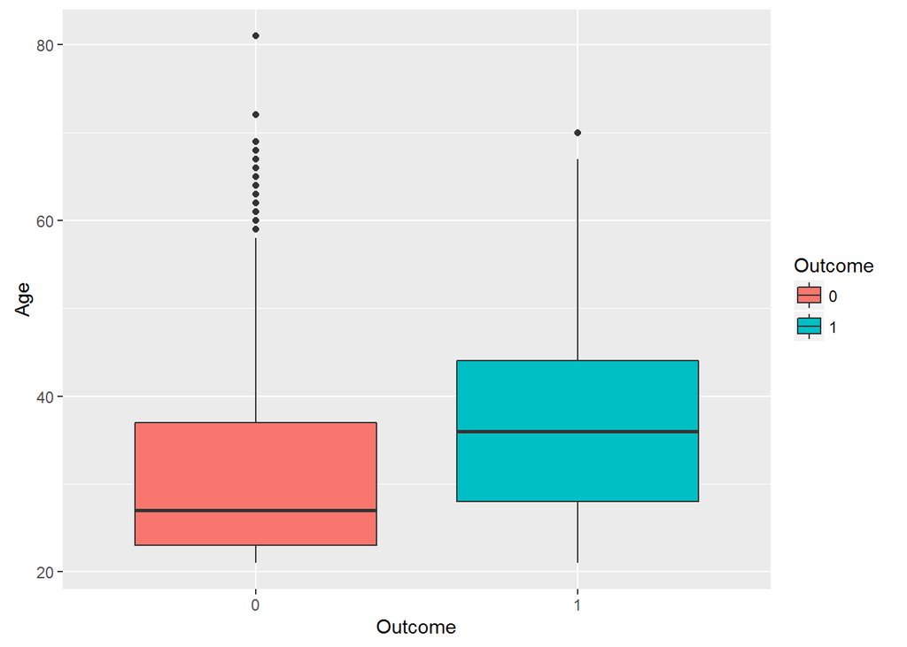

```r
qplot(Outcome,Age,data=diabetes,geom="boxplot",fill=Outcome)
```

The median age of individuals who have diabetes is higher than that of those who do not have diabetes.

## SkinThickness and Blood Pressure

```r
p <- plot_ly(diabetes, x = SkinThickness, y = BloodPressure, name = "Number of Movies by Year",mode = "markers")
p
```

[interactive chart not shown]

There seems to be no discernable relationship here. Let’s try digging deeper by removing outliers from our data.

```r
temp <- diabetes %>% select(SkinThickness,BloodPressure)
qnt <- quantile(temp$SkinThickness, probs=c(.25, .75), na.rm = T)
H <- 1.5 * IQR(temp$SkinThickness, na.rm =T)

temp$SkinThickness <- ifelse(temp$SkinThickness<(qnt[1]-H),NA,temp$SkinThickness)
temp$SkinThickness <- ifelse(temp$SkinThickness>(qnt[2]+H),NA,temp$SkinThickness)
temp$SkinThickness <- ifelse(temp$SkinThickness==0,NA,temp$SkinThickness)
temp<- na.omit(temp)

plot_ly(temp, x = SkinThickness, y = BloodPressure, name = "Skin Thickness vs BloodPressure",mode = "markers") %>%
    add_trace(y = fitted(lm(BloodPressure ~ as.numeric(SkinThickness))), x = SkinThickness)
```

[interactive chart not shown]

By looking at the tilt of the regression line above , we do not see much of a linear relationship here.

## BMI and Skin Thickness

```r
temp <- filter(diabetes,SkinThickness!=0)
ggplotly(ggplot(temp,aes(x=BMI,y=SkinThickness,shape=Outcome,colour=Outcome)) +
  geom_point()+
  scale_shape_manual(values=c(1,2))+
  scale_colour_brewer(palette = "Set2"))
```

[interactive chart not shown]

There seems to be a linear relationship between the skinthickness metric and the Body Mass Index.

```r
cor(temp$SkinThickness,temp$BMI)
```

```
## [1] 0.6319586
```

These two have a correlation of 0.631 which implies linear relationship.

```r
model_0 <- lm(SkinThickness~BMI,data=subset(temp,Outcome==0))
model_1 <- lm(SkinThickness~BMI,data=subset(temp,Outcome==1))
summary(model_0)
```

```
##
## Call:
## lm(formula = SkinThickness ~ BMI, data = subset(temp, Outcome ==
##     0))
##
## Residuals:
##      Min       1Q   Median       3Q      Max
## -19.2946  -4.9912  -0.5129   4.4871  24.8928
##
## Coefficients:
##             Estimate Std. Error t value Pr(>|t|)
## (Intercept) -1.89284    1.87454   -1.01    0.313
## BMI          0.93297    0.05863   15.91   <2e-16 ***
## ---
## Signif. codes:  0 '***' 0.001 '**' 0.01 '*' 0.05 '.' 0.1 ' ' 1
##
## Residual standard error: 7.688 on 359 degrees of freedom
## Multiple R-squared:  0.4136, Adjusted R-squared:  0.412
## F-statistic: 253.3 on 1 and 359 DF,  p-value: < 2.2e-16
```

```r
summary(model_1)
```

```
##
## Call:
## lm(formula = SkinThickness ~ BMI, data = subset(temp, Outcome ==
##     1))
##
## Residuals:
##     Min      1Q  Median      3Q     Max
## -19.296  -5.307  -1.193   5.133  66.962
##
## Coefficients:
##             Estimate Std. Error t value Pr(>|t|)
## (Intercept)   3.9713     3.6794   1.079    0.282
## BMI           0.8089     0.1009   8.020 1.36e-13 ***
## ---
## Signif. codes:  0 '***' 0.001 '**' 0.01 '*' 0.05 '.' 0.1 ' ' 1
##
## Residual standard error: 8.876 on 178 degrees of freedom
## Multiple R-squared:  0.2654, Adjusted R-squared:  0.2613
## F-statistic: 64.32 on 1 and 178 DF,  p-value: 1.361e-13
```

The models can be visualized as follows:

```r
ggplotly(ggplot(temp,aes(x=BMI,y=SkinThickness,colour=Outcome))+
  geom_point()+
  scale_colour_brewer(palette="Set1")+
  geom_smooth(method=lm,se=F,fullrange=T))
```

[interactive chart not shown]

## Glucose and Diabetes

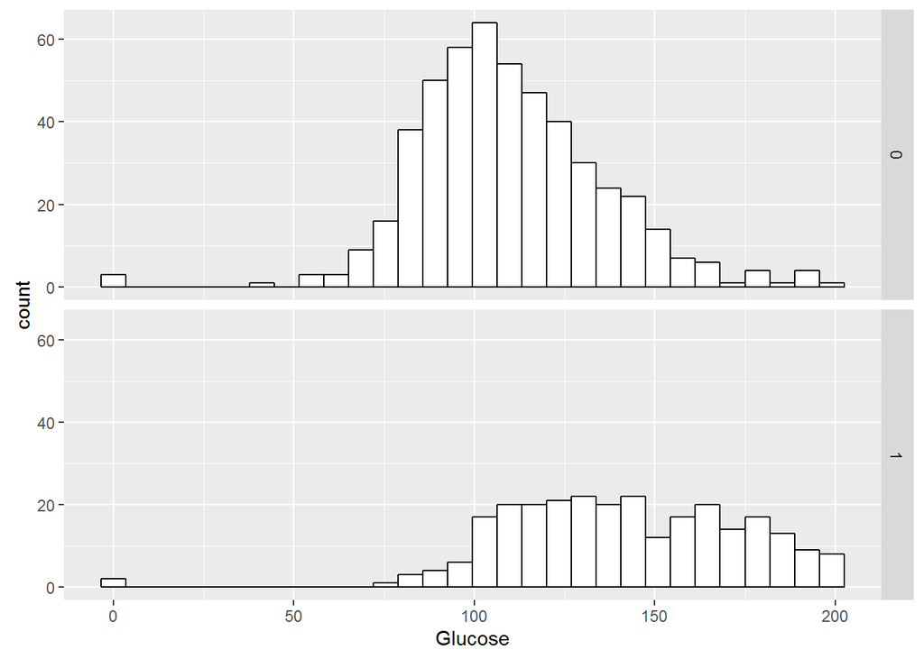

```r
ggplot(diabetes,aes(x=Glucose))+geom_histogram(fill="white",colour="black")+
  facet_grid(Outcome~.)
```

### Conditions

The distributions are skewed but the sample is greater than 30

The individuals are independent of each other

Both the groups are independent of each other

The sample size is lesser than 10% of the population

Let’s formulate a hypothesis to assess the mean difference of glucose levels between the positive and negative groups.

$H0:0$  
$HA:>0$

```r
m0 <- mean(subset(diabetes,Outcome==0)$Glucose)
m1 <- mean(subset(diabetes,Outcome==1)$Glucose)
dim0 <- dim(subset(diabetes,Outcome==0))[1]
dim1 <- dim(subset(diabetes,Outcome==1))[1]
s0 <- sd(subset(diabetes,Outcome==0)$Glucose)
s1 <- sd(subset(diabetes,Outcome==1)$Glucose)
```

Calculating the parameters for the test.

```r
x_bar <- m1-m0
mu <- 0
se <- ((s0^2)/(dim0))+((s1^2)/(dim1))
se <- sqrt(se)
df <- min(dim0-1,dim1-1)
t_stat <- (x_bar-mu)/(se)
pt(t_stat,df=df,lower.tail = F)
```

```
## [1] 3.390826e-33
```

As the p-value fro this test is lesser than the critical values of 0.05, we reject the null hypothesis for the alternate hypothesis. Thus at the 95 % confidence levels we can say that the average glucose levels for individuals with diabetes is greater than that of the people without diabetes.

## Age and Pregnancies

Average pregnancies by age

```r
temp <- diabetes %>% select(Pregnancies,Age)
temp1 <- temp %>% group_by(Age) %>% summarise(n=n(),total_preg = sum(Pregnancies)) %>% mutate(average_preg = total_preg/n) %>% filter(n>5) %>% arrange(desc(average_preg))
kable(temp1)
```

| Age | n | total_preg | average_preg |
| --- | --- | --- | --- |
| 51 | 8 | 69 | 8.625000 |
| 47 | 6 | 50 | 8.333333 |
| 43 | 13 | 101 | 7.769231 |
| 39 | 12 | 89 | 7.416667 |
| 45 | 15 | 110 | 7.333333 |
| 44 | 8 | 58 | 7.250000 |
| 58 | 7 | 50 | 7.142857 |
| 54 | 6 | 42 | 7.000000 |
| 42 | 18 | 124 | 6.888889 |
| 38 | 16 | 110 | 6.875000 |
| 50 | 8 | 54 | 6.750000 |
| 41 | 22 | 143 | 6.500000 |
| 46 | 13 | 83 | 6.384615 |
| 40 | 13 | 81 | 6.230769 |
| 34 | 14 | 82 | 5.857143 |
| 37 | 19 | 100 | 5.263158 |
| 36 | 16 | 83 | 5.187500 |
| 35 | 10 | 50 | 5.000000 |
| 52 | 8 | 37 | 4.625000 |
| 32 | 16 | 71 | 4.437500 |
| 33 | 17 | 69 | 4.058823 |
| 31 | 24 | 93 | 3.875000 |
| 30 | 21 | 76 | 3.619048 |
| 29 | 29 | 96 | 3.310345 |
| 28 | 35 | 106 | 3.028571 |
| 27 | 32 | 82 | 2.562500 |
| 26 | 33 | 65 | 1.969697 |
| 24 | 46 | 87 | 1.891304 |
| 25 | 48 | 85 | 1.770833 |
| 23 | 38 | 60 | 1.578947 |
| 22 | 72 | 112 | 1.555556 |
| 21 | 63 | 68 | 1.079365 |

```r
#ggplotly(ggplot(temp,aes(x=Age,y=n))+geom_line()+geom_point())
```

We see that most individuals were adults and young adults.The oldest individual in this set is of the age 81. The highest average number of pregancies tend to be achieved by women of age 51. In the above table, we have displayed ages that have appeared more than 5 times.

## Predicting Diabetes

The binary logistic model is used to estimate the probability of a binary response based on one or more predictor variables.

```r
set.seed(100)
train <- sample(dim(diabetes)[1],dim(diabetes)[1]*0.9)
diabetes_train <- diabetes[train,]
diabetes_test <- diabetes[-train,]
model <- glm(Outcome~.,data=diabetes_train,family = binomial(link='logit'))
summary(model)
```

```
##
## Call:
## glm(formula = Outcome ~ ., family = binomial(link = "logit"),
##     data = diabetes_train)
##
## Deviance Residuals:
##     Min       1Q   Median       3Q      Max
## -2.5225  -0.7315  -0.4160   0.7303   2.9217
##
## Coefficients:
##                            Estimate Std. Error z value Pr(>|z|)
## (Intercept)              -8.6657540  0.7698286 -11.257  < 2e-16 ***
## Pregnancies               0.1242216  0.0338141   3.674 0.000239 ***
## Glucose                   0.0356658  0.0039212   9.096  < 2e-16 ***
## BloodPressure            -0.0115006  0.0054767  -2.100 0.035737 *
## SkinThickness            -0.0007487  0.0071550  -0.105 0.916665
## Insulin                  -0.0015234  0.0009371  -1.626 0.103998
## BMI                       0.0946089  0.0162731   5.814 6.11e-09 ***
## DiabetesPedigreeFunction  1.0104943  0.3220536   3.138 0.001703 **
## Age                       0.0136741  0.0098036   1.395 0.163075
## ---
## Signif. codes:  0 '***' 0.001 '**' 0.01 '*' 0.05 '.' 0.1 ' ' 1
##
## (Dispersion parameter for binomial family taken to be 1)
##
##     Null deviance: 898.61  on 690  degrees of freedom
## Residual deviance: 651.34  on 682  degrees of freedom
## AIC: 669.34
##
## Number of Fisher Scoring iterations: 5
```

```r
predictions <- predict(model,newdata=diabetes_test,type="response")
predictions <- round(predictions)
mean(predictions==diabetes_test$Outcome)
```

```
## [1] 0.7922078
```

## Improving the Performance

In the previous section we used 0.5 as the threshold for rounding up the result to 1. Do we get a better result by changing the threshold?

```r
threshold <- seq(from=0.1,to=0.9,by=0.01)
j <- 1
accuracy <-c()
for(i in threshold){
  predictions <- predict(model,newdata=diabetes_test,type = 'response')
  predictions <- ifelse(predictions>i,1,0)
  accuracy[j] <- mean(predictions==diabetes_test$Outcome)
  j=j+1

}
model_accuracy <- data.frame(threshold,accuracy)
ggplotly(ggplot(model_accuracy,aes(x=threshold,y = accuracy))+geom_line()+geom_point()+ggtitle("Threshold vs Accuracy"))
```

[interactive chart not shown]

The data frame can be displayed as follows

```r
kable(model_accuracy %>% arrange(desc(accuracy)))
```

| threshold | accuracy |
| --- | --- |
| 0.51 | 0.8181818 |
| 0.52 | 0.8181818 |
| 0.53 | 0.8181818 |
| 0.65 | 0.8181818 |
| 0.66 | 0.8181818 |
| 0.67 | 0.8181818 |
| 0.68 | 0.8181818 |
| 0.49 | 0.8051948 |
| 0.54 | 0.8051948 |
| 0.55 | 0.8051948 |
| 0.56 | 0.8051948 |
| 0.57 | 0.8051948 |
| 0.58 | 0.8051948 |
| 0.59 | 0.8051948 |
| 0.60 | 0.8051948 |
| 0.61 | 0.8051948 |
| 0.62 | 0.8051948 |
| 0.63 | 0.8051948 |
| 0.64 | 0.8051948 |
| 0.69 | 0.8051948 |
| 0.70 | 0.8051948 |
| 0.71 | 0.8051948 |
| 0.72 | 0.8051948 |
| 0.73 | 0.8051948 |
| 0.44 | 0.7922078 |
| 0.48 | 0.7922078 |
| 0.50 | 0.7922078 |
| 0.45 | 0.7792208 |
| 0.46 | 0.7792208 |
| 0.47 | 0.7792208 |

[output cut: 51 more lines]

We achieve an accuracy of 82% in predicting diabetes by using 0.51 as the threshold.